# ML_HW5

2022-11-09

Please click here for the: [Link to the github repository](https://github.com/Donovan-Rasamoelison/Machine_Learning_HW5)

```r
library(tidyverse)
library(tidymodels)
library(janitor)
library(discrim)
library(corrplot)
library(klaR)
library(glmnet)
library(yardstick)

set.seed(0)
```

# Coding questions

## Question 1 - using clean_names() on pokemon data

```r
pokemon <- read.csv("Pokemon.csv") %>% clean_names()
```

The clean_names() function renames the variables in the Pokemon data to be lower case and follow the snake case format. It can make referring to the variables easier.

## Question 2 - Bar chart for type_1

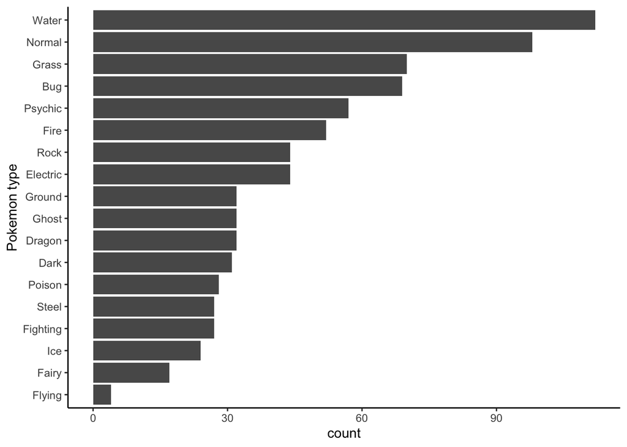

```r
pokemon %>% ggplot(aes(y = fct_reorder(as.factor(type_1),type_1,.fun='length'))) +
  geom_bar() +
  ylab("Pokemon type") +
  theme_classic()
```

```r
pokemon %>% count(fct_reorder(as.factor(type_1),type_1,.fun='length')) # looking at the number of types and the types with few observation
```

```
##    fct_reorder(as.factor(type_1), type_1, .fun = "length")   n
## 1                                                   Flying   4
## 2                                                    Fairy  17
## 3                                                      Ice  24
## 4                                                 Fighting  27
## 5                                                    Steel  27
## 6                                                   Poison  28
## 7                                                     Dark  31
## 8                                                   Dragon  32
## 9                                                    Ghost  32
## 10                                                  Ground  32
## 11                                                Electric  44
## 12                                                    Rock  44
## 13                                                    Fire  52
## 14                                                 Psychic  57
## 15                                                     Bug  69
## 16                                                   Grass  70
## 17                                                  Normal  98
## 18                                                   Water 112
```

```r
pokemon_clean <- pokemon %>%
  filter(type_1 %in% c("Bug","Fire","Grass","Normal","Water","Psychic")) %>% #filtering to only include selected types
  mutate(across(c(type_1,legendary), ~ as.factor(.))) #making type_1 and legendary factor

#checking results
is.factor(pokemon_clean$type_1)
```

```
## [1] TRUE
```

```r
is.factor(pokemon_clean$legendary)
```

```
## [1] TRUE
```

```r
pokemon_clean %>% count(fct_reorder(as.factor(type_1),type_1,.fun='length'))
```

```
##   fct_reorder(as.factor(type_1), type_1, .fun = "length")   n
## 1                                                    Fire  52
## 2                                                 Psychic  57
## 3                                                     Bug  69
## 4                                                   Grass  70
## 5                                                  Normal  98
## 6                                                   Water 112
```

There are 18 different classes of Pokemon. Flying class has very few observation, only 4. Fairy class also has very few observations (17)

## Question 3 - Splitting the data and creating folds.

```r
#Splitting the data
pokemon_split <- initial_split(pokemon_clean, prop = 0.8, strata = "type_1")
pokemon_clean_train <- training(pokemon_split)
pokemon_clean_test  <- testing(pokemon_split)

#Checking if the training and test sets have the appropriate number of observations.
dim(pokemon_clean_train) #364 = this is 80% of 458
```

```
## [1] 364  13
```

```r
dim(pokemon_clean_test) #94 = this is 20% of 458
```

```
## [1] 94 13
```

```r
#V-fold cross validation (k=5)
pokemon_clean_fold <- vfold_cv(pokemon_clean_train, v=5, strata = "type_1")
```

Stratifying over the outcome is necessary to have a balanced number of the outcome classes in the folds.

## Question 4 - Setting up a recipe

```r
pokemon_clean_recipe <- recipe(formula = type_1 ~ legendary + generation + sp_atk + attack + speed + defense + hp + sp_def, data = pokemon_clean_train) %>%
  step_dummy(legendary, generation) %>%
  step_center(all_predictors()) %>%
  step_normalize(all_predictors())
```

## Question 5 - Setting model and workflow

```r
pokemon_model <- multinom_reg(penalty = tune(), mixture = tune()) %>%
  set_mode("classification") %>%
  set_engine("glmnet")

pokemon_workflow <- workflow() %>%
  add_recipe(pokemon_clean_recipe) %>%
  add_model(pokemon_model)

penalty_grid <- grid_regular(penalty(range = c(-5,5)), mixture(range = c(0,1)),levels = 10)
```

We will be fitting 100 models for the combination of each penalty and mixture. But on the folded data, we have 5 folds, so in total we will fit 500 models.

## Question 6 -

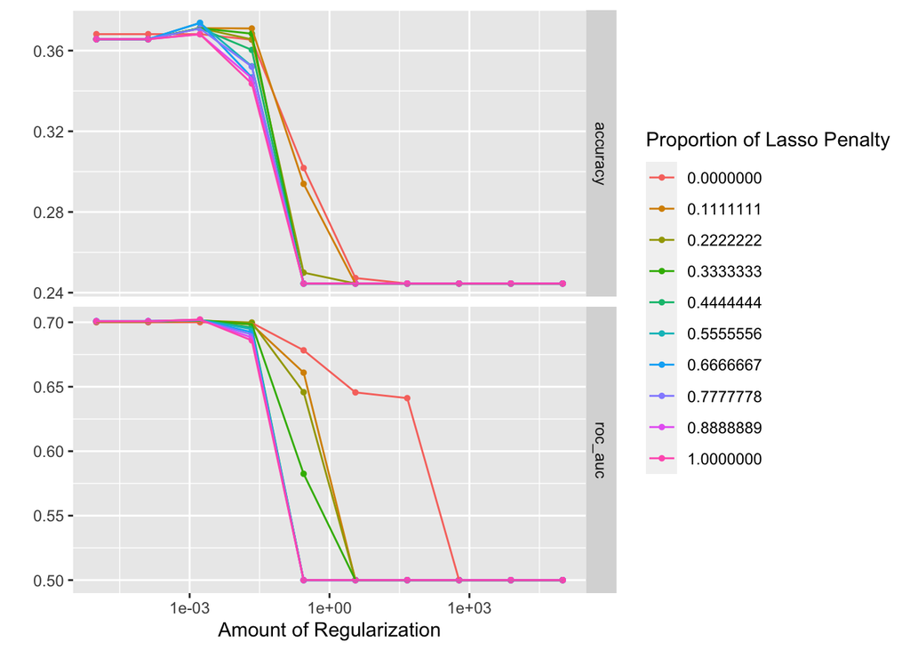

```r
tune_res <- tune_grid(pokemon_workflow, resamples = pokemon_clean_fold, grid = penalty_grid)
autoplot(tune_res)
```

We can see that larger values of penalty and mixture do not produce a better accuracy and ROC AUC values.

## Question 7 - Selecting the best model parameter and fitting on the test set

```r
#Selecting the best parameters
best_penalty <- select_best(tune_res, metric = "roc_auc")
best_penalty
```

```
## # A tibble: 1 × 3
##   penalty mixture .config
##     <dbl>   <dbl> <chr>
## 1 0.00167       1 Preprocessor1_Model093
```

```r
#Fitting the model to the test data and evaluating its performance using accuracy measure
pokemon_model_final <- finalize_workflow(pokemon_workflow,best_penalty)

pokemon_model_final_fit <- fit(pokemon_model_final, data = pokemon_clean_train)

#measuring accuracy
augment(pokemon_model_final_fit, new_data = pokemon_clean_test) %>% accuracy(truth = type_1, estimate = .pred_class)
```

```
## # A tibble: 1 × 3
##   .metric  .estimator .estimate
##   <chr>    <chr>          <dbl>
## 1 accuracy multiclass     0.394
```

## Question 8 -

```r
#ROC AUC for the testing set
augment(pokemon_model_final_fit, new_data = pokemon_clean_test) %>% roc_auc(truth = type_1, estimate = .pred_Bug:.pred_Water)
```

```
## # A tibble: 1 × 3
##   .metric .estimator .estimate
##   <chr>   <chr>          <dbl>
## 1 roc_auc hand_till      0.748
```

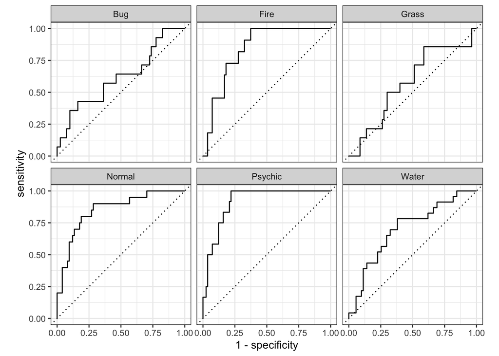

```r
#ROC AUC for each level of the outcome
augment(pokemon_model_final_fit, new_data = pokemon_clean_test) %>% roc_curve(truth = type_1, estimate = .pred_Bug:.pred_Water) %>% autoplot()
```

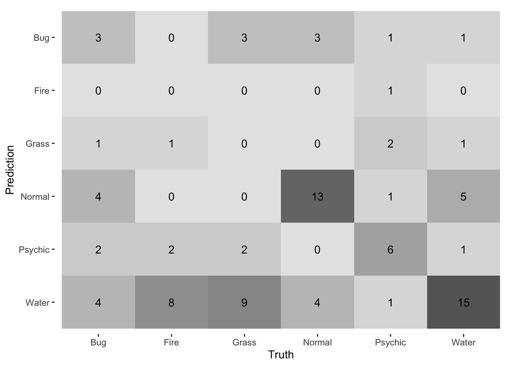

```r
#heatmap of the confusion matrix
augment(pokemon_model_final_fit, new_data = pokemon_clean_test) %>% conf_mat(truth = type_1, estimate = .pred_class) %>% autoplot(type = "heatmap")
```

# 231 students only:

## Question 9

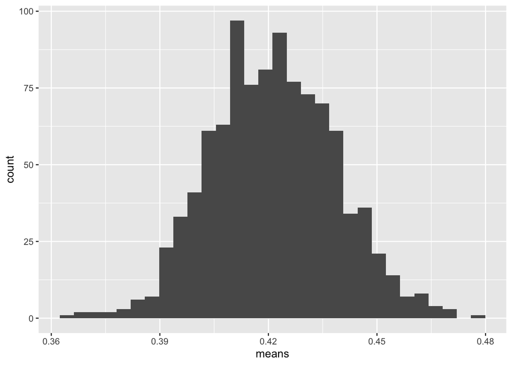

```r
sample_curry <- c(rep(1,337),rep(0,464))
means <- NULL

for (i in 1:1000) {
  means[i] <- mean(sample(sample_curry,replace=T)) #Sampling with replacement and computing the mean
}

ggplot(aes(x = means), data = tibble(means)) +
  geom_histogram()
```

```r
#mean
mean(means)
```

```
## [1] 0.4214432
```

```r
#Confidence interval
c(quantile(means, 0.005), quantile(means, 0.995))
```

```
##      0.5%     99.5%
## 0.3757678 0.4644320
```